# Practica1Real

HENC

2023-10-12

```r
library(pacman)
p_load(haven, dplyr, lavaan, semTools)
```

# Cargamos los datos de pobreza 2014 del CONEVAL (“pobreza_14sample.dta”).

```r
library(haven)
Dm<-read_dta("pobreza_14sample.dta")
names(Dm)
```

```
##   [1] "proyecto"        "folioviv"        "foliohog"        "numren"
##   [5] "parentesco"      "edad"            "indigena"        "anac_e"
##   [9] "educ_hh"         "educ_hh2"        "educ_hh3"        "educ_hh4"
##  [13] "educ_hh5"        "inas_esc"        "niv_ed"          "ic_rezedu"
##  [17] "hli"             "sexo"            "ic_asalud"       "serv_sal"
##  [21] "discap"          "pea"             "ss_dir"          "par"
##  [25] "jef_ss"          "cony_ss"         "hijo_ss"         "s_salud"
##  [29] "pam"             "ic_segsoc"       "icv_muros"       "icv_techos"
##  [33] "icv_pisos"       "icv_hac"         "ic_cv"           "isb_agua"
##  [37] "isb_dren"        "isb_luz"         "isb_combus"      "ic_sbv"
##  [41] "ia_1ad"          "ia_2ad"          "ia_3ad"          "ia_4ad"
##  [45] "ia_5ad"          "ia_6ad"          "ia_7men"         "ia_8men"
##  [49] "ia_9men"         "ia_10men"        "ia_11men"        "ia_12men"
##  [53] "id_men"          "tot_iaad"        "tot_iamen"       "ins_ali"
##  [57] "ic_ali"          "tv_dep"          "radio_dep"       "fridge_dep"
##  [61] "washingmach_dep" "compu_dep"       "inter_dep"       "ubica_geo"
##  [65] "TAM_LOC"         "est_dis"         "psu"             "weight"
##  [69] "tot_integ"       "ing_mon"         "ing_lab"         "ing_ren"
##  [73] "ing_tra"         "rururb"          "pago_esp"        "reg_esp"
##  [77] "nomon"           "ict"             "tamhogesc"       "ictpc"
##  [81] "plb_m"           "plb"             "ent"             "i_privacion"
##  [85] "pobreza"         "pobreza_e"       "pobreza_m"       "vul_car"
##  [89] "vul_ing"         "no_pobv"         "carencias"       "carencias3"
##  [93] "cuadrantes"      "prof_b1"         "prof_bm1"        "profun"
##  [97] "int_pob"         "int_pobe"        "int_vulcar"      "int_caren"
## [101] "hh_id"           "EDOMUN"          "EDOMUN_n"        "EDO"
## [105] "EDO_n"           "one"             "totalp"          "totalw"
## [109] "scalling"        "nweight"         "sweight"         "tag"
## [113] "durables"
```

# Paso 1: Definición del modelo estrctural

```r
m.1<-"f1 =~ isb_agua +  isb_dren +  isb_luz + isb_combus
      f2 =~ icv_muros + icv_techos +  icv_pisos + icv_hac
      f3 =~ ia_1ad + ia_2ad + ia_3ad + ia_4ad + ia_5ad + ia_6ad
      Mp =~ f1 + f2 + f3"
```

```r
r.1<-sem(m.1, data=Dm, ordered=T, sampling.weights = "weight")
```

```r
summary(r.1, fit.measures=TRUE, standardized=TRUE, rsquare=TRUE)
```

```
## lavaan 0.6.16 ended normally after 61 iterations
##
##   Estimator                                       DWLS
##   Optimization method                           NLMINB
##   Number of model parameters                        31
##
##                                                   Used       Total
##   Number of observations                          9999       10000
##   Sampling weights variable                     weight
##
## Model Test User Model:
##                                               Standard      Scaled
##   Test Statistic                               197.938     192.516
##   Degrees of freedom                                74          74
##   P-value (Chi-square)                           0.000       0.000
##   Scaling correction factor                                  1.223
##   Shift parameter                                           30.725
##     simple second-order correction
##
## Model Test Baseline Model:
##
##   Test statistic                             93078.671   51489.447
##   Degrees of freedom                                91          91
##   P-value                                        0.000       0.000
##   Scaling correction factor                                  1.809
##
## User Model versus Baseline Model:
##
##   Comparative Fit Index (CFI)                    0.999       0.998
##   Tucker-Lewis Index (TLI)                       0.998       0.997
##
##   Robust Comparative Fit Index (CFI)                         0.910
##   Robust Tucker-Lewis Index (TLI)                            0.890
##
## Root Mean Square Error of Approximation:
##
##   RMSEA                                          0.013       0.013
##   90 Percent confidence interval - lower         0.011       0.010
##   90 Percent confidence interval - upper         0.015       0.015
##   P-value H_0: RMSEA <= 0.050                    1.000       1.000
```

[output cut: 122 more lines]

```
##     isb_luz           0.450
##     isb_combus        0.666
##     icv_muros         0.377
##     icv_techos        0.346
##     icv_pisos         0.590
##     icv_hac           0.264
##     ia_1ad            0.831
##     ia_2ad            0.915
##     ia_3ad            0.912
##     ia_4ad            0.779
##     ia_5ad            0.852
##     ia_6ad            0.847
##     f1                0.871
##     f2                0.864
##     f3                0.210
```

La confiabilidad total de la escala ($\omega_t$, omegaL1) es igual a .64 de acuerdo con `reliabilityL2`.

La confiabilidad total de las dimensiones atribuible al primer factor ($\omega_t$, omegaL2) es igual a .76 de acuerdo con `reliabilityL2`.

```r
reliability(r.1)
```

```
## For constructs with categorical indicators, Zumbo et al.`s (2007) "ordinal alpha" is calculated in addition to the standard alpha, which treats ordinal variables as numeric. See Chalmers (2018) for a critique of "alpha.ord" and the response by Zumbo & Kroc (2019). Likewise, average variance extra…
```

```
##                  f1        f2        f3
## alpha     0.4946286 0.3466239 0.8851091
## alpha.ord 0.8124100 0.7255461 0.9712003
## omega     0.5532740 0.3221739 0.9046038
## omega2    0.5532740 0.3221739 0.9046038
## omega3    0.5513154 0.3230001 0.9078598
## avevar    0.5187946 0.3942335 0.8559842
```

```r
reliabilityL2(r.1, "Mp")
```

```
##        omegaL1        omegaL2 partialOmegaL1
##      0.6432800      0.7662778      0.9157911
```

La confiabilidad total del factor general (h) ($\omega_{h}$) se obtiene con la función `compRelSEM(r.1, higher = "Mp", ord.scale = F)`. Es igual a .648 (Valor sobrestimado).

```r
compRelSEM(r.1, higher = "Mp", ord.scale = F)
```

```
##    f1    f2    f3    Mp
## 0.803 0.703 0.978 0.648
```

# Diagramas

```r
#install.packages("devtools")
#devtools::install_github("alishinski/lavaanPlot")
library(lavaanPlot)

lavaanPlot(model = r.1, node_options = list(shape = "box", fontname = "Helvetica"),
            edge_options = list(color = "grey"), coefs = T,
            stand = TRUE, graph_options = list(rankdir = "LR"))
```

[interactive chart not shown]

# Scores factoriales con valores perdidos

Al igual que en el caso unidimensional podemos producir los scores factoriales (scores óptimos dado el modelo) con la función `lavPredict`.

```r
Dm %>% filter_at(vars(isb_combus), all_vars(!is.na(.))) -> Dmp
Dmp$pred.1<-lavPredict(r.1, newdata=Dmp)
```

Si revisamos las primeras filas de la columna `pred.1`, nos daremos cuenta que se generaron cuatro nuevas variables (si, variables dentro de variables). Estas contienen los scores de los tres factores y del factor general.

```r
head(Dmp$pred.1)
```

```
##               f1          f2          f3           Mp
## [1,]  0.30492736  0.42327224  0.43293936  0.347624261
## [2,] -0.15562108 -0.14638567 -0.28188126 -0.147237497
## [3,]  0.61751309  0.48518258  0.36554233  0.520892354
## [4,]  0.50981376  0.76055052 -0.06316716  0.584729088
## [5,] -0.02021837 -0.01112129  0.32679611 -0.006017777
## [6,] -0.15562108 -0.14638567 -0.28188126 -0.147237497
```

# Segundo modelo

Cargamos los datos de pobreza 2018 del CONEVAL (“pobreza_18sample.dta”).

```r
Dm18<-read_dta("pobreza_18sample.dta")
names(Dm18)
```

```
##  [1] "folioviv"    "foliohog"    "numren"      "factor"      "tam_loc"
##  [6] "rururb"      "ent"         "ubica_geo"   "edad"        "sexo"
## [11] "tamhogesc"   "parentesco"  "niv_edexpjh" "edad_jh"     "sex_jh"
## [16] "ic_rezedu"   "anac_e"      "inas_esc"    "niv_ed"      "ic_asalud"
## [21] "sa_dir"      "ic_segsoc"   "ss_dir"      "pea"         "par"
## [26] "jef_ss"      "cony_ss"     "hijo_ss"     "s_salud"     "pam"
## [31] "ic_cv"       "icv_pisos"   "icv_muros"   "icv_techos"  "icv_hac"
## [36] "ic_sbv"      "isb_agua"    "isb_dren"    "isb_luz"     "isb_combus"
## [41] "ic_ali"      "id_men"      "tot_iaad"    "tot_iamen"   "ins_ali"
## [46] "plb_m"       "plb"         "ictpc"       "ictpc_tp"    "est_dis"
## [51] "upm"         "i_privacion" "pobreza"     "pobreza_e"   "pobreza_m"
## [56] "vul_car"     "vul_ing"     "no_pobv"     "carencias"   "carencias3"
## [61] "cuadrantes"  "prof_b1"     "prof_bm1"    "profun"      "int_pob"
## [66] "int_pobe"    "int_vulcar"  "int_caren"   "ict"         "ing_mon"
## [71] "ing_mon_tp"  "ing_lab"     "ing_ren"     "ing_tra"     "ing_trap"
## [76] "nomon"       "pago_esp"    "reg_esp"     "hli"         "discap"
## [81] "POS_OCU"     "SCIAN"       "T_TRA"       "sinco1"      "sinco2"
## [86] "tipo_trab1"  "tipo_trab2"  "CS_P13_1"    "totalp"      "totalw"
## [91] "scalling"    "nweight"     "sweight"     "one"         "random"
## [96] "insample"
```

```r
m.2<-"Mp =~ ic_ali + ic_rezedu + ic_asalud + ic_segsoc + ic_cv + ic_sbv"
```

```r
r.2<-sem(m.2, data=Dm18, ordered=T, sampling.weights = "factor")
```

```r
summary(r.2, fit.measures=TRUE, standardized=TRUE, rsquare=TRUE)
```

```
## lavaan 0.6.16 ended normally after 35 iterations
##
##   Estimator                                       DWLS
##   Optimization method                           NLMINB
##   Number of model parameters                        12
##
##   Number of observations                         10000
##   Sampling weights variable                     factor
##
## Model Test User Model:
##                                               Standard      Scaled
##   Test Statistic                               839.441     967.298
##   Degrees of freedom                                 9           9
##   P-value (Chi-square)                           0.000       0.000
##   Scaling correction factor                                  0.868
##   Shift parameter                                            0.603
##     simple second-order correction
##
## Model Test Baseline Model:
##
##   Test statistic                              3684.595    3346.592
##   Degrees of freedom                                15          15
##   P-value                                        0.000       0.000
##   Scaling correction factor                                  1.101
##
## User Model versus Baseline Model:
##
##   Comparative Fit Index (CFI)                    0.774       0.712
##   Tucker-Lewis Index (TLI)                       0.623       0.521
##
##   Robust Comparative Fit Index (CFI)                         0.468
##   Robust Tucker-Lewis Index (TLI)                            0.114
##
## Root Mean Square Error of Approximation:
##
##   RMSEA                                          0.096       0.103
##   90 Percent confidence interval - lower         0.091       0.098
##   90 Percent confidence interval - upper         0.102       0.109
##   P-value H_0: RMSEA <= 0.050                    0.000       0.000
##   P-value H_0: RMSEA >= 0.080                    1.000       1.000
```

[output cut: 58 more lines]

```
##     ic_ali            1.000                               1.000    1.000
##     ic_rezedu         1.000                               1.000    1.000
##     ic_asalud         1.000                               1.000    1.000
##     ic_segsoc         1.000                               1.000    1.000
##     ic_cv             1.000                               1.000    1.000
##     ic_sbv            1.000                               1.000    1.000
##
## R-Square:
##                    Estimate
##     ic_ali            0.166
##     ic_rezedu         0.215
##     ic_asalud         0.268
##     ic_segsoc         0.470
##     ic_cv             0.400
##     ic_sbv            0.520
```

```r
reliability(r.2)
```

```
## For constructs with categorical indicators, Zumbo et al.`s (2007) "ordinal alpha" is calculated in addition to the standard alpha, which treats ordinal variables as numeric. See Chalmers (2018) for a critique of "alpha.ord" and the response by Zumbo & Kroc (2019). Likewise, average variance extra…
```

```
##                  Mp
## alpha     0.4793639
## alpha.ord 0.7040659
## omega     0.5570936
## omega2    0.5570936
## omega3    0.5857625
## avevar    0.3397795
```

```r
Dm18$pred.2<-lavPredict(r.2, newdata=Dm18)
```

¿Qué es lo que está pasando? No parece que la confiabilidad afecte el ordenamiento.

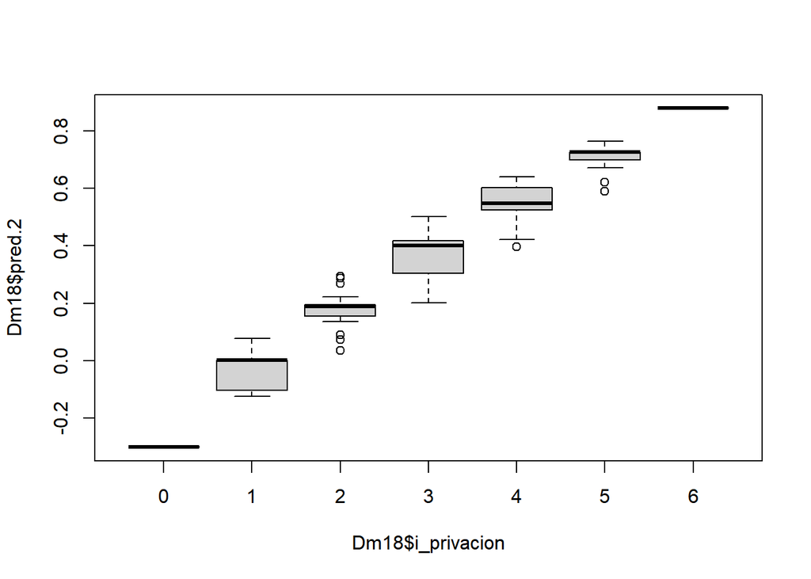

```r
boxplot(Dm18$pred.2~Dm18$i_privacion)
```

Las variables latentes están estandarizadas. Lo que queremos es buena cobertura. Solamente tenemos información para el 33% de lo que nos gustaría saber. Es demasiado compacta esta escala.

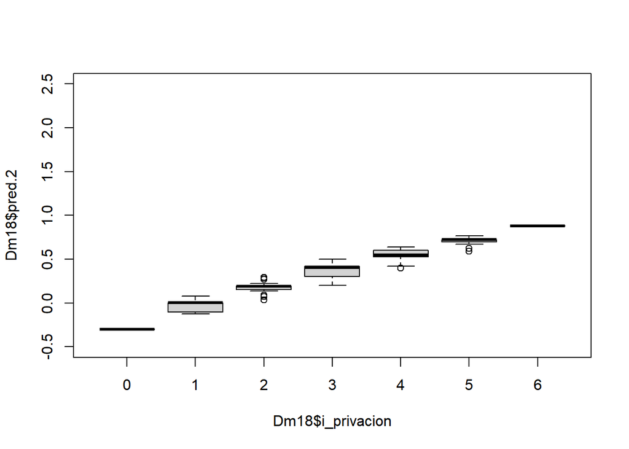

```r
boxplot(Dm18$pred.2~Dm18$i_privacion, ylim=c(-.5,2.5))
```

## El efecto de la seguridad social

```r
m.3<-"Mp =~ ic_ali + ic_rezedu + ic_asalud  + ic_cv + ic_sbv"
```

```r
r.3<-sem(m.3, data=Dm18, ordered=T, sampling.weights = "factor")
```

```r
summary(r.3, fit.measures=TRUE, standardized=TRUE, rsquare=TRUE)
```

```
## lavaan 0.6.16 ended normally after 28 iterations
##
##   Estimator                                       DWLS
##   Optimization method                           NLMINB
##   Number of model parameters                        10
##
##   Number of observations                         10000
##   Sampling weights variable                     factor
##
## Model Test User Model:
##                                               Standard      Scaled
##   Test Statistic                                 7.352       9.968
##   Degrees of freedom                                 5           5
##   P-value (Chi-square)                           0.196       0.076
##   Scaling correction factor                                  0.744
##   Shift parameter                                            0.082
##     simple second-order correction
##
## Model Test Baseline Model:
##
##   Test statistic                              1819.877    1692.126
##   Degrees of freedom                                10          10
##   P-value                                        0.000       0.000
##   Scaling correction factor                                  1.076
##
## User Model versus Baseline Model:
##
##   Comparative Fit Index (CFI)                    0.999       0.997
##   Tucker-Lewis Index (TLI)                       0.997       0.994
##
##   Robust Comparative Fit Index (CFI)                         0.989
##   Robust Tucker-Lewis Index (TLI)                            0.977
##
## Root Mean Square Error of Approximation:
##
##   RMSEA                                          0.007       0.010
##   90 Percent confidence interval - lower         0.000       0.000
##   90 Percent confidence interval - upper         0.017       0.019
##   P-value H_0: RMSEA <= 0.050                    1.000       1.000
##   P-value H_0: RMSEA >= 0.080                    0.000       0.000
```

[output cut: 52 more lines]

```
## Scales y*:
##                    Estimate  Std.Err  z-value  P(>|z|)   Std.lv  Std.all
##     ic_ali            1.000                               1.000    1.000
##     ic_rezedu         1.000                               1.000    1.000
##     ic_asalud         1.000                               1.000    1.000
##     ic_cv             1.000                               1.000    1.000
##     ic_sbv            1.000                               1.000    1.000
##
## R-Square:
##                    Estimate
##     ic_ali            0.212
##     ic_rezedu         0.340
##     ic_asalud         0.003
##     ic_cv             0.418
##     ic_sbv            0.695
```

```r
reliability(r.3)
```

```
## For constructs with categorical indicators, Zumbo et al.`s (2007) "ordinal alpha" is calculated in addition to the standard alpha, which treats ordinal variables as numeric. See Chalmers (2018) for a critique of "alpha.ord" and the response by Zumbo & Kroc (2019). Likewise, average variance extra…
```

```
##                  Mp
## alpha     0.4069876
## alpha.ord 0.6261432
## omega     0.4702283
## omega2    0.4702283
## omega3    0.4701767
## avevar    0.3337519
```

```r
Dm18$pred.3<-lavPredict(r.3, newdata=Dm18)
```

```r
Dm18$i_privacionB<-rowSums(Dm18[,c("ic_ali","ic_rezedu", "ic_asalud", "ic_cv","ic_sbv")])
```

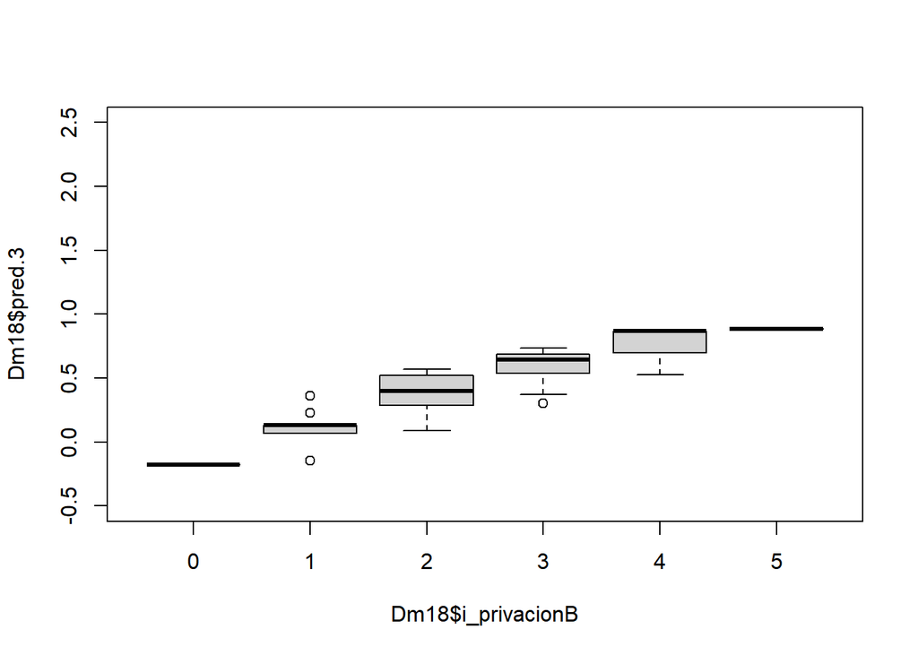

```r
boxplot(Dm18$pred.3~Dm18$i_privacionB, ylim=c(-.5,2.5))
```

# El modelo más próximo del CONEVAL

Bajo este modelo. Las cargas factoriales son iguales. El modelo intentará encontrar la mejor solución posible dada esta condición, i.e. el máximo valor de las cargas factoriales, dado que son iguales.

```r
m.4<-"Mp =~ 1*ic_ali + 1*ic_rezedu + 1*ic_asalud + 1*ic_segsoc + 1*ic_cv + 1*ic_sbv"
```

```r
r.4<-sem(m.4, data=Dm18, ordered=T, sampling.weights = "factor")
```

```r
summary(r.4, fit.measures=TRUE, standardized=TRUE, rsquare=TRUE)
```

```
## lavaan 0.6.16 ended normally after 2 iterations
##
##   Estimator                                       DWLS
##   Optimization method                           NLMINB
##   Number of model parameters                         7
##
##   Number of observations                         10000
##   Sampling weights variable                     factor
##
## Model Test User Model:
##                                               Standard      Scaled
##   Test Statistic                              1034.364    1046.067
##   Degrees of freedom                                14          14
##   P-value (Chi-square)                           0.000       0.000
##   Scaling correction factor                                  0.990
##   Shift parameter                                            0.902
##     simple second-order correction
##
## Model Test Baseline Model:
##
##   Test statistic                              3684.595    3346.592
##   Degrees of freedom                                15          15
##   P-value                                        0.000       0.000
##   Scaling correction factor                                  1.101
##
## User Model versus Baseline Model:
##
##   Comparative Fit Index (CFI)                    0.722       0.690
##   Tucker-Lewis Index (TLI)                       0.702       0.668
##
##   Robust Comparative Fit Index (CFI)                         0.400
##   Robust Tucker-Lewis Index (TLI)                            0.357
##
## Root Mean Square Error of Approximation:
##
##   RMSEA                                          0.085       0.086
##   90 Percent confidence interval - lower         0.081       0.081
##   90 Percent confidence interval - upper         0.090       0.090
##   P-value H_0: RMSEA <= 0.050                    0.000       0.000
##   P-value H_0: RMSEA >= 0.080                    0.978       0.986
```

[output cut: 58 more lines]

```
##     ic_ali            1.000                               1.000    1.000
##     ic_rezedu         1.000                               1.000    1.000
##     ic_asalud         1.000                               1.000    1.000
##     ic_segsoc         1.000                               1.000    1.000
##     ic_cv             1.000                               1.000    1.000
##     ic_sbv            1.000                               1.000    1.000
##
## R-Square:
##                    Estimate
##     ic_ali            0.330
##     ic_rezedu         0.330
##     ic_asalud         0.330
##     ic_segsoc         0.330
##     ic_cv             0.330
##     ic_sbv            0.330
```

```r
reliability(r.4)
```

```
## For constructs with categorical indicators, Zumbo et al.`s (2007) "ordinal alpha" is calculated in addition to the standard alpha, which treats ordinal variables as numeric. See Chalmers (2018) for a critique of "alpha.ord" and the response by Zumbo & Kroc (2019). Likewise, average variance extra…
```

```
##                  Mp
## alpha     0.4793639
## alpha.ord 0.7040659
## omega     0.5540006
## omega2    0.5540006
## omega3    0.5898427
## avevar    0.3299224
```

```r
Dm18$pred.4<-lavPredict(r.4, newdata=Dm18)
```

¿Qué es lo que está pasando? No parece que la confiabilidad afecte el ordenamiento.

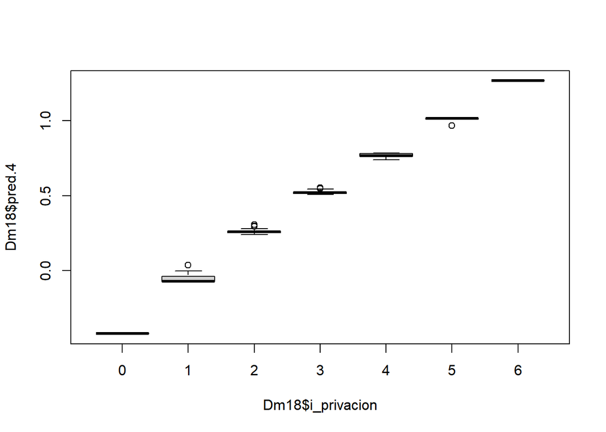

```r
boxplot(Dm18$pred.4~Dm18$i_privacion)
```

Las variables latentes están estandarizadas. Lo que queremos es buena cobertura. Solamente tenemos información para el 33% de lo que nos gustaría saber. Es demasiado compacta esta escala.

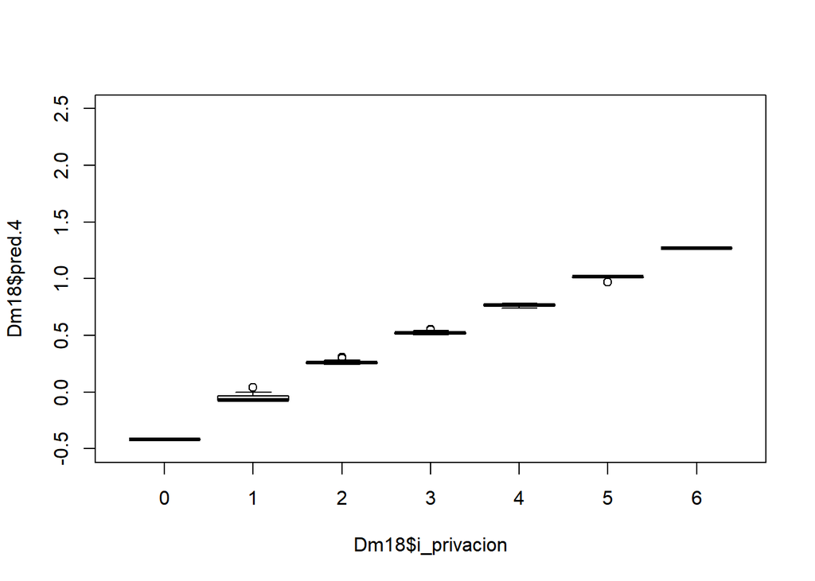

```r
boxplot(Dm18$pred.4~Dm18$i_privacion, ylim=c(-.5,2.5))
```

## Extra 1: Problemas en el contexto de regresión

```r
library(data.table)
D<-fread("Sim_data_1_1.dat")
```

```r
head(D)
```

```
##    V1 V2 V3 V4 V5 V6 V7 V8 V9 V10 V11 V12 V13 V14 V15       V16      V17
## 1:  0  0  0  0  0  0  0  1  0   0   0   0   0   0   0  4.282589 2.906683
## 2:  0  0  0  0  0  0  0  0  0   0   1   0   0   0   0  6.359577 2.932446
## 3:  0  0  0  0  0  0  0  0  0   0   0   0   0   0   0  4.251600 5.950873
## 4:  0  0  0  0  0  0  0  0  0   0   0   0   0   0   0  6.264688 8.604143
## 5:  0  0  0  0  0  0  0  0  0   0   0   0   0   0   0 -0.532331 2.690857
## 6:  0  0  0  0  0  0  0  0  0   0   0   0   0   0   0  5.914512 1.653447
##          V18      V19       V20
## 1:  1.359892 4.355836  1.490452
## 2:  8.442417 3.413640  1.182619
## 3:  5.035065 3.294149  0.987248
## 4:  2.629497 5.316279 -0.422520
## 5: -0.762698 5.878410  0.337926
## 6:  2.998187 2.479318 -0.249493
```

Genero dos escalas. Sé que la primera es menos confiable que la segunda.

```r
D$obs.score.ur<-rowSums(D[,3:9])
D$obs.score.re<-rowSums(D[,1:6])
```

Cargamos la libreria `MASS`.

```r
library(MASS)
```

Usamos la función `polr()` para estimar modelos ordinales con cinco predictores: V16:V20.

```r
coef.ur<-summary(polr(as.factor(obs.score.ur) ~ V16  +     V17   +   V18  +    V19    +   V20, data=D))
```

```
##
## Re-fitting to get Hessian
```

```r
coef.re<-summary(polr(as.factor(obs.score.re) ~ V16  +     V17   +   V18  +    V19    +   V20, data=D))
```

```
##
## Re-fitting to get Hessian
```

## Gráfica:

La gráfica de abajo se hace con el paquete `ggplot2` con la función `ggplot()`. Lo que tenemos que hacer es extraer los coeficientes, crear una base de datos con los mismos y pasar los argumentos necesarios a la función para graficar.

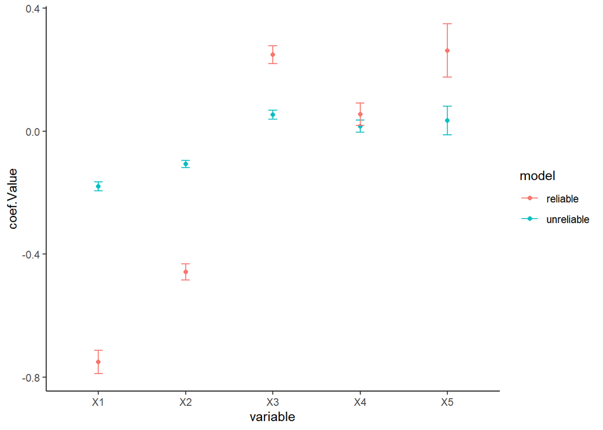

```r
library(ggplot2)
coef<-data.frame(coef=rbind(coef.ur$coefficients[1:5,],coef.re$coefficients[1:5,]), model=rep(c("unreliable","reliable"), each=5))
coef$variable<-rep(c("X1","X2","X3","X4","X5"), 2)
ggplot(coef, aes(variable, coef.Value, color=model)) + geom_point() + geom_errorbar(aes(ymin=coef.Value-c(`coef.Std..Error`*1.96),
                                                                                        ymax=coef.Value+c(`coef.Std..Error`*1.96)), width=.1) + theme_classic()
```

## Extra 2: ¿Escalas equivalentes con items diferentes?

Creamos diferentes escalas. En principio, las tres primeras son más confiables y más parecidas que la última.

```r
D$obs.score.re3<-rowSums(D[,c(1:5,10:12)])
D$obs.score.re4<-rowSums(D[,c(1:5,13:15)])
D$obs.score.re5<-rowSums(D[,c(1:6,10,15)])
D$obs.score.re6<-rowSums(D[,c(3:9)])
```

Estimamos los modelos con la función `plor`.

```r
coef.re3<-summary(polr(as.factor(obs.score.re3) ~ V16  +     V17   +   V18  +    V19    +   V20, data=D))
```

```
##
## Re-fitting to get Hessian
```

```r
coef.re4<-summary(polr(as.factor(obs.score.re4) ~ V16  +     V17   +   V18  +    V19    +   V20, data=D))
```

```
##
## Re-fitting to get Hessian
```

```r
coef.re5<-summary(polr(as.factor(obs.score.re5) ~ V16  +     V17   +   V18  +    V19    +   V20, data=D))
```

```
##
## Re-fitting to get Hessian
```

```r
coef.ur6<-summary(polr(as.factor(obs.score.re6) ~ V16  +     V17   +   V18  +    V19    +   V20, data=D))
```

```
##
## Re-fitting to get Hessian
```

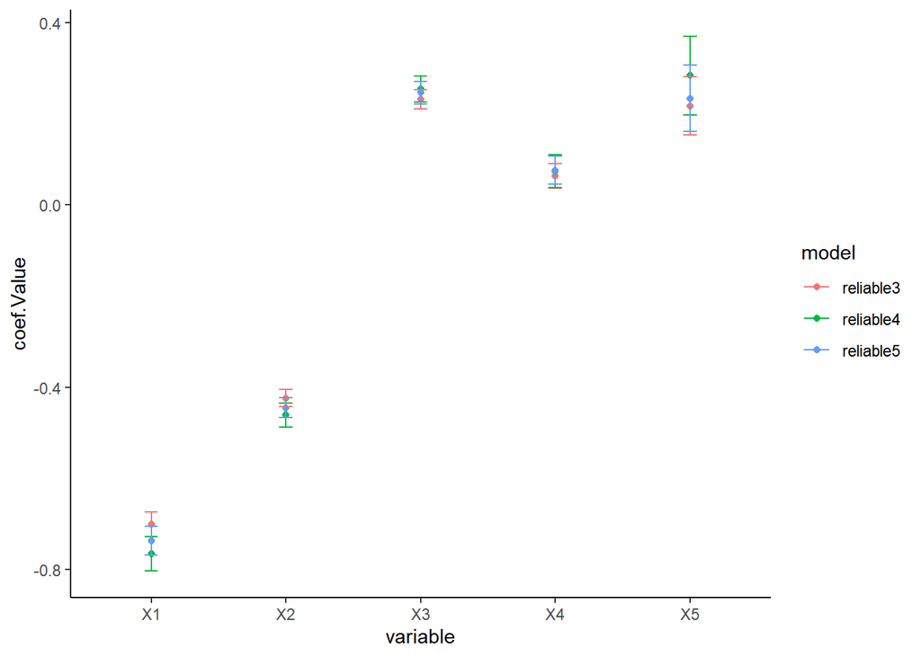

```r
coef<-data.frame(coef=rbind(coef.re3$coefficients[1:5,],coef.re4$coefficients[1:5,],coef.re5$coefficients[1:5,]), model=rep(c("reliable3","reliable4","reliable5"), each=5))
coef$variable<-rep(c("X1","X2","X3","X4","X5"), 3)
ggplot(coef, aes(variable, coef.Value, color=model)) + geom_point() + geom_errorbar(aes(ymin=coef.Value-c(`coef.Std..Error`*1.96),
                                                                                        ymax=coef.Value+c(`coef.Std..Error`*1.96)), width=.1) + theme_classic()
```

El error de medición es malo para sus modelos.

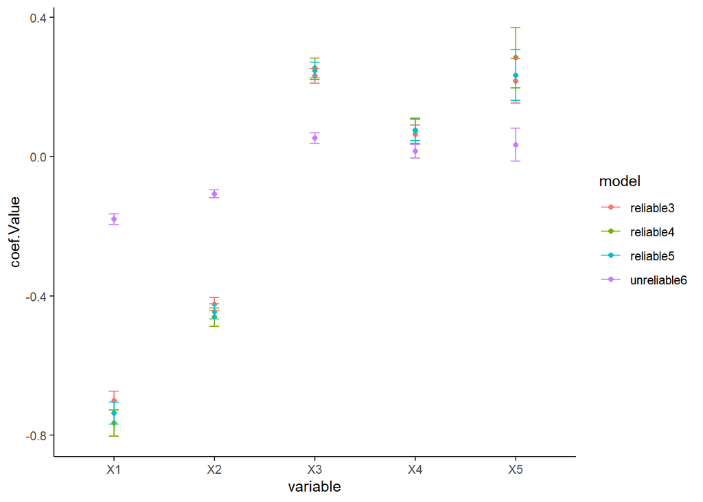

```r
coef<-data.frame(coef=rbind(coef.re3$coefficients[1:5,],coef.re4$coefficients[1:5,],coef.re5$coefficients[1:5,],coef.ur6$coefficients[1:5,]), model=rep(c("reliable3","reliable4","reliable5","unreliable6"), each=5))
coef$variable<-rep(c("X1","X2","X3","X4","X5"), 4)
ggplot(coef, aes(variable, coef.Value, color=model)) + geom_point() + geom_errorbar(aes(ymin=coef.Value-c(`coef.Std..Error`*1.96),
                                                                                        ymax=coef.Value+c(`coef.Std..Error`*1.96)), width=.1) + theme_classic()
```